# Risk Factor Analysis

## Outcome Variable

**Outcome Variable:** stunted

## Predictor Variables

**Intervention Variable:** fhtcm

**Adjustment Set:**

unadjusted

## Stratifying Variables

The analysis was stratified on these variable(s):

- agecat
- studyid
- country

## Data Summary

| agecat | studyid | country | fhtcm | stunted | n_cell | n |
| --- | --- | --- | --- | --- | --- | --- |
| Birth | COHORTS | GUATEMALA | >=167 cm | 0 | 26 | 206 |
| Birth | COHORTS | GUATEMALA | >=167 cm | 1 | 3 | 206 |
| Birth | COHORTS | GUATEMALA | <162 cm | 0 | 111 | 206 |
| Birth | COHORTS | GUATEMALA | <162 cm | 1 | 10 | 206 |
| Birth | COHORTS | GUATEMALA | [162-167) cm | 0 | 54 | 206 |
| Birth | COHORTS | GUATEMALA | [162-167) cm | 1 | 2 | 206 |
| Birth | Keneba | GAMBIA | >=167 cm | 0 | 735 | 1167 |
| Birth | Keneba | GAMBIA | >=167 cm | 1 | 37 | 1167 |
| Birth | Keneba | GAMBIA | <162 cm | 0 | 82 | 1167 |
| Birth | Keneba | GAMBIA | <162 cm | 1 | 5 | 1167 |
| Birth | Keneba | GAMBIA | [162-167) cm | 0 | 291 | 1167 |
| Birth | Keneba | GAMBIA | [162-167) cm | 1 | 17 | 1167 |
| Birth | PROBIT | BELARUS | >=167 cm | 0 | 11713 | 12535 |
| Birth | PROBIT | BELARUS | >=167 cm | 1 | 29 | 12535 |
| Birth | PROBIT | BELARUS | <162 cm | 0 | 168 | 12535 |
| Birth | PROBIT | BELARUS | <162 cm | 1 | 0 | 12535 |
| Birth | PROBIT | BELARUS | [162-167) cm | 0 | 621 | 12535 |
| Birth | PROBIT | BELARUS | [162-167) cm | 1 | 4 | 12535 |
| Birth | SAS-CompFeed | INDIA | >=167 cm | 0 | 253 | 746 |
| Birth | SAS-CompFeed | INDIA | >=167 cm | 1 | 90 | 746 |
| Birth | SAS-CompFeed | INDIA | <162 cm | 0 | 126 | 746 |
| Birth | SAS-CompFeed | INDIA | <162 cm | 1 | 64 | 746 |
| Birth | SAS-CompFeed | INDIA | [162-167) cm | 0 | 148 | 746 |
| Birth | SAS-CompFeed | INDIA | [162-167) cm | 1 | 65 | 746 |
| 6 months | COHORTS | GUATEMALA | >=167 cm | 0 | 31 | 336 |
| 6 months | COHORTS | GUATEMALA | >=167 cm | 1 | 14 | 336 |
| 6 months | COHORTS | GUATEMALA | <162 cm | 0 | 88 | 336 |
| 6 months | COHORTS | GUATEMALA | <162 cm | 1 | 109 | 336 |
| 6 months | COHORTS | GUATEMALA | [162-167) cm | 0 | 61 | 336 |
| 6 months | COHORTS | GUATEMALA | [162-167) cm | 1 | 33 | 336 |
| 6 months | Keneba | GAMBIA | >=167 cm | 0 | 849 | 1511 |
| 6 months | Keneba | GAMBIA | >=167 cm | 1 | 130 | 1511 |
| 6 months | Keneba | GAMBIA | <162 cm | 0 | 98 | 1511 |
| 6 months | Keneba | GAMBIA | <162 cm | 1 | 15 | 1511 |
| 6 months | Keneba | GAMBIA | [162-167) cm | 0 | 355 | 1511 |
| 6 months | Keneba | GAMBIA | [162-167) cm | 1 | 64 | 1511 |
| 6 months | PROBIT | BELARUS | >=167 cm | 0 | 10763 | 11894 |
| 6 months | PROBIT | BELARUS | >=167 cm | 1 | 383 | 11894 |
| 6 months | PROBIT | BELARUS | <162 cm | 0 | 141 | 11894 |
| 6 months | PROBIT | BELARUS | <162 cm | 1 | 15 | 11894 |
| 6 months | PROBIT | BELARUS | [162-167) cm | 0 | 554 | 11894 |
| 6 months | PROBIT | BELARUS | [162-167) cm | 1 | 38 | 11894 |
| 6 months | SAS-CompFeed | INDIA | >=167 cm | 0 | 281 | 807 |
| 6 months | SAS-CompFeed | INDIA | >=167 cm | 1 | 88 | 807 |
| 6 months | SAS-CompFeed | INDIA | <162 cm | 0 | 129 | 807 |
| 6 months | SAS-CompFeed | INDIA | <162 cm | 1 | 65 | 807 |
| 6 months | SAS-CompFeed | INDIA | [162-167) cm | 0 | 168 | 807 |
| 6 months | SAS-CompFeed | INDIA | [162-167) cm | 1 | 76 | 807 |
| 6 months | SAS-FoodSuppl | INDIA | >=167 cm | 0 | 64 | 372 |
| 6 months | SAS-FoodSuppl | INDIA | >=167 cm | 1 | 38 | 372 |
| 6 months | SAS-FoodSuppl | INDIA | <162 cm | 0 | 72 | 372 |
| 6 months | SAS-FoodSuppl | INDIA | <162 cm | 1 | 76 | 372 |
| 6 months | SAS-FoodSuppl | INDIA | [162-167) cm | 0 | 77 | 372 |
| 6 months | SAS-FoodSuppl | INDIA | [162-167) cm | 1 | 45 | 372 |
| 24 months | COHORTS | GUATEMALA | >=167 cm | 0 | 24 | 526 |
| 24 months | COHORTS | GUATEMALA | >=167 cm | 1 | 46 | 526 |
| 24 months | COHORTS | GUATEMALA | <162 cm | 0 | 40 | 526 |
| 24 months | COHORTS | GUATEMALA | <162 cm | 1 | 267 | 526 |
| 24 months | COHORTS | GUATEMALA | [162-167) cm | 0 | 36 | 526 |
| 24 months | COHORTS | GUATEMALA | [162-167) cm | 1 | 113 | 526 |
| 24 months | Keneba | GAMBIA | >=167 cm | 0 | 565 | 1297 |
| 24 months | Keneba | GAMBIA | >=167 cm | 1 | 256 | 1297 |
| 24 months | Keneba | GAMBIA | <162 cm | 0 | 63 | 1297 |
| 24 months | Keneba | GAMBIA | <162 cm | 1 | 34 | 1297 |
| 24 months | Keneba | GAMBIA | [162-167) cm | 0 | 216 | 1297 |
| 24 months | Keneba | GAMBIA | [162-167) cm | 1 | 163 | 1297 |
| 24 months | PROBIT | BELARUS | >=167 cm | 0 | 3228 | 3670 |
| 24 months | PROBIT | BELARUS | >=167 cm | 1 | 217 | 3670 |
| 24 months | PROBIT | BELARUS | <162 cm | 0 | 42 | 3670 |
| 24 months | PROBIT | BELARUS | <162 cm | 1 | 11 | 3670 |
| 24 months | PROBIT | BELARUS | [162-167) cm | 0 | 150 | 3670 |
| 24 months | PROBIT | BELARUS | [162-167) cm | 1 | 22 | 3670 |

The following strata were considered:

- agecat: 24 months, studyid: COHORTS, country: GUATEMALA
- agecat: 24 months, studyid: Keneba, country: GAMBIA
- agecat: 24 months, studyid: PROBIT, country: BELARUS
- agecat: 6 months, studyid: COHORTS, country: GUATEMALA
- agecat: 6 months, studyid: Keneba, country: GAMBIA
- agecat: 6 months, studyid: PROBIT, country: BELARUS
- agecat: 6 months, studyid: SAS-CompFeed, country: INDIA
- agecat: 6 months, studyid: SAS-FoodSuppl, country: INDIA
- agecat: Birth, studyid: COHORTS, country: GUATEMALA
- agecat: Birth, studyid: Keneba, country: GAMBIA
- agecat: Birth, studyid: PROBIT, country: BELARUS
- agecat: Birth, studyid: SAS-CompFeed, country: INDIA

### Dropped Strata

Some strata were dropped due to rare outcomes:

- agecat: Birth, studyid: COHORTS, country: GUATEMALA
- agecat: Birth, studyid: PROBIT, country: BELARUS

## Methods Detail

We’re interested in the causal parameters $E[Y_a]$ for all values of $a \in \mathcal{A}$. These parameters represent the mean outcome if, possibly contrary to fact, we intervened to set all units to have $A=a$. Under the randomization and positivity assumptions, these are identified by the statistical parameters $\psi_a=E_W[E_{Y|A,W}(Y|A=a,W)]$. In addition, we’re interested in the mean of $Y$, $E[Y]$ under no intervention (the observed mean). We will estimate these parameters by using SuperLearner to fit the relevant likelihood factors – $E_{Y|A,W}(Y|A=a,W)$ and $p(A=a|W)$, and then updating our likelihood fit using a joint TMLE.

For unadjusted analyses ($W=\{\}$), initial likelihoods were estimated using Lrnr_glm to estimate the simple $E(Y|A)$ and Lrnr_mean to estimate $p(A)$. For adjusted analyses, a small library containing Lrnr_glmnet, Lrnr_xgboost, and Lrnr_mean was used.

Having estimated these parameters, we will then use the delta method to estimate relative risks and attributable risks relative to a prespecified baseline level of $A$.

# Results Detail

## Results Plots

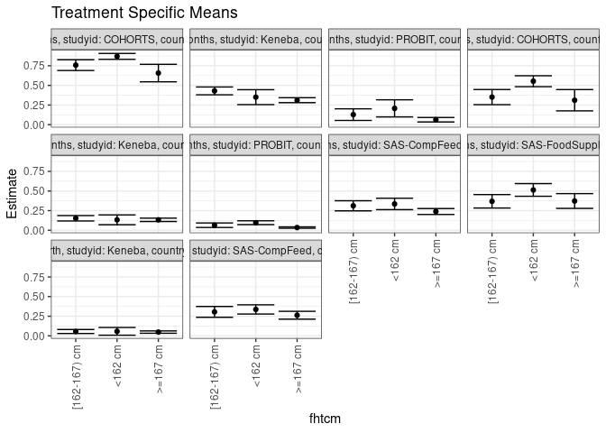

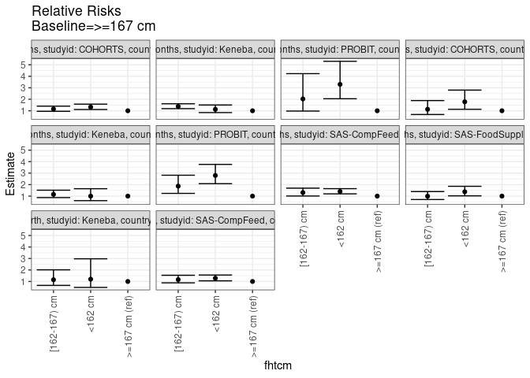

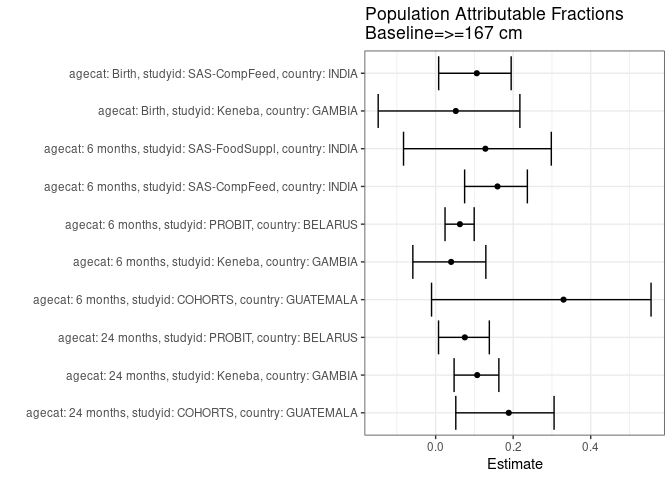

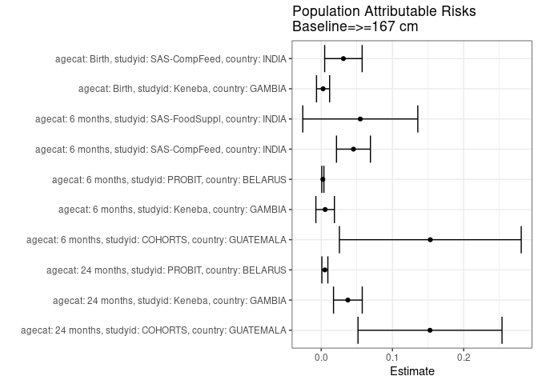

## Results Table

### Parameter: TSM

| agecat | studyid | country | intervention_level | baseline_level | estimate | ci_lower | ci_upper |
| --- | --- | --- | --- | --- | --- | --- | --- |
| Birth | Keneba | GAMBIA | >=167 cm | NA | 0.0479275 | 0.0328526 | 0.0630023 |
| Birth | Keneba | GAMBIA | <162 cm | NA | 0.0574713 | 0.0085444 | 0.1063981 |
| Birth | Keneba | GAMBIA | [162-167) cm | NA | 0.0551948 | 0.0296808 | 0.0807088 |
| Birth | SAS-CompFeed | INDIA | >=167 cm | NA | 0.2623907 | 0.2124843 | 0.3122971 |
| Birth | SAS-CompFeed | INDIA | <162 cm | NA | 0.3368421 | 0.2782656 | 0.3954186 |
| Birth | SAS-CompFeed | INDIA | [162-167) cm | NA | 0.3051643 | 0.2363113 | 0.3740173 |
| 6 months | COHORTS | GUATEMALA | >=167 cm | NA | 0.3111111 | 0.1756479 | 0.4465743 |
| 6 months | COHORTS | GUATEMALA | <162 cm | NA | 0.5532995 | 0.4837730 | 0.6228260 |
| 6 months | COHORTS | GUATEMALA | [162-167) cm | NA | 0.3510638 | 0.2544308 | 0.4476968 |
| 6 months | Keneba | GAMBIA | >=167 cm | NA | 0.1327886 | 0.1115246 | 0.1540525 |
| 6 months | Keneba | GAMBIA | <162 cm | NA | 0.1327434 | 0.0701638 | 0.1953230 |
| 6 months | Keneba | GAMBIA | [162-167) cm | NA | 0.1527446 | 0.1182878 | 0.1872014 |
| 6 months | PROBIT | BELARUS | >=167 cm | NA | 0.0343621 | 0.0255947 | 0.0431295 |
| 6 months | PROBIT | BELARUS | <162 cm | NA | 0.0961538 | 0.0718025 | 0.1205052 |
| 6 months | PROBIT | BELARUS | [162-167) cm | NA | 0.0641892 | 0.0355813 | 0.0927970 |
| 6 months | SAS-CompFeed | INDIA | >=167 cm | NA | 0.2384824 | 0.2006277 | 0.2763371 |
| 6 months | SAS-CompFeed | INDIA | <162 cm | NA | 0.3350515 | 0.2623570 | 0.4077461 |
| 6 months | SAS-CompFeed | INDIA | [162-167) cm | NA | 0.3114754 | 0.2471012 | 0.3758496 |
| 6 months | SAS-FoodSuppl | INDIA | >=167 cm | NA | 0.3725490 | 0.2785953 | 0.4665028 |
| 6 months | SAS-FoodSuppl | INDIA | <162 cm | NA | 0.5135135 | 0.4328805 | 0.5941466 |
| 6 months | SAS-FoodSuppl | INDIA | [162-167) cm | NA | 0.3688525 | 0.2831202 | 0.4545848 |
| 24 months | COHORTS | GUATEMALA | >=167 cm | NA | 0.6571429 | 0.5458419 | 0.7684438 |
| 24 months | COHORTS | GUATEMALA | <162 cm | NA | 0.8697068 | 0.8320157 | 0.9073980 |
| 24 months | COHORTS | GUATEMALA | [162-167) cm | NA | 0.7583893 | 0.6895918 | 0.8271867 |
| 24 months | Keneba | GAMBIA | >=167 cm | NA | 0.3118149 | 0.2801159 | 0.3435138 |
| 24 months | Keneba | GAMBIA | <162 cm | NA | 0.3505155 | 0.2555277 | 0.4455032 |
| 24 months | Keneba | GAMBIA | [162-167) cm | NA | 0.4300792 | 0.3802163 | 0.4799420 |
| 24 months | PROBIT | BELARUS | >=167 cm | NA | 0.0629898 | 0.0343995 | 0.0915802 |
| 24 months | PROBIT | BELARUS | <162 cm | NA | 0.2075472 | 0.0986539 | 0.3164405 |
| 24 months | PROBIT | BELARUS | [162-167) cm | NA | 0.1279070 | 0.0539645 | 0.2018495 |

### Parameter: E(Y)

| agecat | studyid | country | intervention_level | baseline_level | estimate | ci_lower | ci_upper |
| --- | --- | --- | --- | --- | --- | --- | --- |
| Birth | Keneba | GAMBIA | NA | NA | 0.0505570 | 0.0379815 | 0.0631324 |
| Birth | SAS-CompFeed | INDIA | NA | NA | 0.2935657 | 0.2562276 | 0.3309038 |
| 6 months | COHORTS | GUATEMALA | NA | NA | 0.4642857 | 0.4108803 | 0.5176911 |
| 6 months | Keneba | GAMBIA | NA | NA | 0.1383190 | 0.1209060 | 0.1557320 |
| 6 months | PROBIT | BELARUS | NA | NA | 0.0366571 | 0.0273774 | 0.0459369 |
| 6 months | SAS-CompFeed | INDIA | NA | NA | 0.2837670 | 0.2471555 | 0.3203786 |
| 6 months | SAS-FoodSuppl | INDIA | NA | NA | 0.4274194 | 0.3770801 | 0.4777586 |
| 24 months | COHORTS | GUATEMALA | NA | NA | 0.8098859 | 0.7763209 | 0.8434510 |
| 24 months | Keneba | GAMBIA | NA | NA | 0.3492675 | 0.3233122 | 0.3752228 |
| 24 months | PROBIT | BELARUS | NA | NA | 0.0681199 | 0.0392337 | 0.0970061 |

### Parameter: RR

| agecat | studyid | country | intervention_level | baseline_level | estimate | ci_lower | ci_upper |
| --- | --- | --- | --- | --- | --- | --- | --- |
| Birth | Keneba | GAMBIA | >=167 cm | >=167 cm | 1.0000000 | 1.0000000 | 1.000000 |
| Birth | Keneba | GAMBIA | <162 cm | >=167 cm | 1.1991302 | 0.4838515 | 2.971807 |
| Birth | Keneba | GAMBIA | [162-167) cm | >=167 cm | 1.1516322 | 0.6584043 | 2.014350 |
| Birth | SAS-CompFeed | INDIA | >=167 cm | >=167 cm | 1.0000000 | 1.0000000 | 1.000000 |
| Birth | SAS-CompFeed | INDIA | <162 cm | >=167 cm | 1.2837427 | 1.0555961 | 1.561199 |
| Birth | SAS-CompFeed | INDIA | [162-167) cm | >=167 cm | 1.1630151 | 0.8785387 | 1.539607 |
| 6 months | COHORTS | GUATEMALA | >=167 cm | >=167 cm | 1.0000000 | 1.0000000 | 1.000000 |
| 6 months | COHORTS | GUATEMALA | <162 cm | >=167 cm | 1.7784627 | 1.1303897 | 2.798088 |
| 6 months | COHORTS | GUATEMALA | [162-167) cm | >=167 cm | 1.1284195 | 0.6741461 | 1.888805 |
| 6 months | Keneba | GAMBIA | >=167 cm | >=167 cm | 1.0000000 | 1.0000000 | 1.000000 |
| 6 months | Keneba | GAMBIA | <162 cm | >=167 cm | 0.9996596 | 0.6076065 | 1.644682 |
| 6 months | Keneba | GAMBIA | [162-167) cm | >=167 cm | 1.1502846 | 0.8722901 | 1.516874 |
| 6 months | PROBIT | BELARUS | >=167 cm | >=167 cm | 1.0000000 | 1.0000000 | 1.000000 |
| 6 months | PROBIT | BELARUS | <162 cm | >=167 cm | 2.7982527 | 2.0829732 | 3.759155 |
| 6 months | PROBIT | BELARUS | [162-167) cm | >=167 cm | 1.8680227 | 1.2380338 | 2.818589 |
| 6 months | SAS-CompFeed | INDIA | >=167 cm | >=167 cm | 1.0000000 | 1.0000000 | 1.000000 |
| 6 months | SAS-CompFeed | INDIA | <162 cm | >=167 cm | 1.4049321 | 1.1967308 | 1.649355 |
| 6 months | SAS-CompFeed | INDIA | [162-167) cm | >=167 cm | 1.3060730 | 1.0084750 | 1.691491 |
| 6 months | SAS-FoodSuppl | INDIA | >=167 cm | >=167 cm | 1.0000000 | 1.0000000 | 1.000000 |
| 6 months | SAS-FoodSuppl | INDIA | <162 cm | >=167 cm | 1.3783784 | 1.0241137 | 1.855191 |
| 6 months | SAS-FoodSuppl | INDIA | [162-167) cm | >=167 cm | 0.9900777 | 0.7026223 | 1.395136 |
| 24 months | COHORTS | GUATEMALA | >=167 cm | >=167 cm | 1.0000000 | 1.0000000 | 1.000000 |
| 24 months | COHORTS | GUATEMALA | <162 cm | >=167 cm | 1.3234669 | 1.1111852 | 1.576303 |
| 24 months | COHORTS | GUATEMALA | [162-167) cm | >=167 cm | 1.1540706 | 0.9523340 | 1.398542 |
| 24 months | Keneba | GAMBIA | >=167 cm | >=167 cm | 1.0000000 | 1.0000000 | 1.000000 |
| 24 months | Keneba | GAMBIA | <162 cm | >=167 cm | 1.1241140 | 0.8416088 | 1.501449 |
| 24 months | Keneba | GAMBIA | [162-167) cm | >=167 cm | 1.3792773 | 1.1821838 | 1.609230 |
| 24 months | PROBIT | BELARUS | >=167 cm | >=167 cm | 1.0000000 | 1.0000000 | 1.000000 |
| 24 months | PROBIT | BELARUS | <162 cm | >=167 cm | 3.2949309 | 2.0464560 | 5.305059 |
| 24 months | PROBIT | BELARUS | [162-167) cm | >=167 cm | 2.0305969 | 0.9742889 | 4.232137 |

### Parameter: PAR

| agecat | studyid | country | intervention_level | baseline_level | estimate | ci_lower | ci_upper |
| --- | --- | --- | --- | --- | --- | --- | --- |
| Birth | Keneba | GAMBIA | >=167 cm | NA | 0.0026295 | -0.0065753 | 0.0118343 |
| Birth | SAS-CompFeed | INDIA | >=167 cm | NA | 0.0311750 | 0.0048673 | 0.0574827 |
| 6 months | COHORTS | GUATEMALA | >=167 cm | NA | 0.1531746 | 0.0255534 | 0.2807958 |
| 6 months | Keneba | GAMBIA | >=167 cm | NA | 0.0055304 | -0.0074869 | 0.0185478 |
| 6 months | PROBIT | BELARUS | >=167 cm | NA | 0.0022950 | 0.0007843 | 0.0038058 |
| 6 months | SAS-CompFeed | INDIA | >=167 cm | NA | 0.0452847 | 0.0214626 | 0.0691068 |
| 6 months | SAS-FoodSuppl | INDIA | >=167 cm | NA | 0.0548703 | -0.0258797 | 0.1356203 |
| 24 months | COHORTS | GUATEMALA | >=167 cm | NA | 0.1527431 | 0.0516622 | 0.2538240 |
| 24 months | Keneba | GAMBIA | >=167 cm | NA | 0.0374527 | 0.0172934 | 0.0576119 |
| 24 months | PROBIT | BELARUS | >=167 cm | NA | 0.0051301 | 0.0009144 | 0.0093457 |

### Parameter: PAF

| agecat | studyid | country | intervention_level | baseline_level | estimate | ci_lower | ci_upper |
| --- | --- | --- | --- | --- | --- | --- | --- |
| Birth | Keneba | GAMBIA | >=167 cm | NA | 0.0520111 | -0.1482148 | 0.2173215 |
| Birth | SAS-CompFeed | INDIA | >=167 cm | NA | 0.1061943 | 0.0078114 | 0.1948219 |
| 6 months | COHORTS | GUATEMALA | >=167 cm | NA | 0.3299145 | -0.0105470 | 0.5556718 |
| 6 months | Keneba | GAMBIA | >=167 cm | NA | 0.0399832 | -0.0587926 | 0.1295441 |
| 6 months | PROBIT | BELARUS | >=167 cm | NA | 0.0626081 | 0.0242615 | 0.0994477 |
| 6 months | SAS-CompFeed | INDIA | >=167 cm | NA | 0.1595839 | 0.0747613 | 0.2366303 |
| 6 months | SAS-FoodSuppl | INDIA | >=167 cm | NA | 0.1283759 | -0.0828128 | 0.2983749 |
| 24 months | COHORTS | GUATEMALA | >=167 cm | NA | 0.1885983 | 0.0519990 | 0.3055146 |
| 24 months | Keneba | GAMBIA | >=167 cm | NA | 0.1072321 | 0.0476312 | 0.1631030 |
| 24 months | PROBIT | BELARUS | >=167 cm | NA | 0.0753091 | 0.0074749 | 0.1385072 |